# MultiAmplicon - a real world example

Emanuel Heitlinger

2021-01-17

## Data preparation (download and filtering)

We first [download the data](https://svalbard.biologie.hu-berlin.de:443/d/c291b870178f4abc8c59/) set from consisting of 192 fastq file-pairs from 18S and 16S amplicon sequencing of feces and intestinal contents of carnivores (hyenas and wolves). Use the botton on the upper right of the page to download a zipped folder and unzip it after downloading. The help file for the [`carnivoreSeqRuns`](https://derele.github.io/MultiAmplicon/reference/carnivoreSeqRuns.html) (containing sample data included in the package), shows how this data has been downloaded from [NCBI-SRA](https://www.ncbi.nlm.nih.gov/bioproject/PRJNA386767).

Now we can run our standard workflow. But as usual with real data we have to filter the input files first. This particular sequencing was of quite low quality, so we have to trim and screen quite harshly.

```r
library(MultiAmplicon)
## And we'll also use some dada2 functions directly
library(dada2)
path <- "download_sra" ## change according to where you downloaded

fastqFiles <- list.files(path, pattern=".fastq.gz$", full.names=TRUE)

fastqF <- grep("_1.fastq.gz", fastqFiles, value = TRUE)
fastqR <- grep("_2.fastq.gz", fastqFiles, value = TRUE)

samples <- gsub("_1.fastq\\.gz", "\\1", basename(fastqF))

filt_path <- "filtered_sra"
if(!file_test("-d", filt_path)) dir.create(filt_path)

filtFs <- file.path(filt_path, paste0(samples, "_F_filt.fastq.gz"))
names(filtFs) <- samples
filtRs <- file.path(filt_path, paste0(samples, "_R_filt.fastq.gz"))
names(filtRs) <- samples

## some files will be filtered out completely, therefore allowing 50
## files less present and still don't redo filtering
redo <- sum(file.exists(fastqF)) -
    sum(file.exists(filtFs)) > 50

if(redo){
    lapply(seq_along(fastqF),  function (i) {
        filterAndTrim(fastqF[i], filtFs[i], fastqR[i], filtRs[i],
                      truncLen=c(170,170), minLen=c(170,170),
                      maxN=0, maxEE=2, truncQ=2,
                      compress=TRUE, verbose=TRUE)
    })
}

names(filtFs) <- names(filtRs) <- samples

files <- PairedReadFileSet(filtFs, filtRs)
```

## Data preparation (primer set)

Now we have our sequencing read input data, only the primers are still missing. The primer set for the above is included in the MultiAmplicon package. The data has been generated using a microfluidics PCR system, if you want to know more about this you can consult [Heitlinger et al. (2017)](https://www.ncbi.nlm.nih.gov/pmc/articles/PMC5472691/) or [Lesniak et al. (2017)](https://www.ncbi.nlm.nih.gov/pmc/articles/PMC5269671/).

```r
primer.file <- system.file("extdata", "real_world_primers.csv",
                           package = "MultiAmplicon")

ptable <- read.csv(primer.file, sep=",", header=TRUE, stringsAsFactors=FALSE)

primerF <- ptable[, "TS.SequenceF"]
primerR <- ptable[, "TS.SequenceR"]

names(primerF) <- as.character(ptable[, "corrected.NameF"])
names(primerR) <- as.character(ptable[, "corrected.NameR"])

primers <- PrimerPairsSet(primerF, primerR)

MA <- MultiAmplicon(primers, files)
```

## Running the MultiAmplicon pipeline

We start by sorting our amplicons by primer sequences cutting off the latter from sequencing reads. The directory for sorted amplicons must be empty before that.

```r
filedir <- "stratified_files"
if(dir.exists(filedir)) unlink(filedir, recursive=TRUE)
MA <- sortAmplicons(MA, n=1e+05, filedir=filedir)
```

The function is “streaming” fastq files, so that potentially large files can be handled on machines with modest memory. The parameter “n” controls how big the streamed chunks are. Increasing this value leads to faster processing and higher memory usage.

```r
errF <- learnErrors(unlist(getStratifiedFilesF(MA)), nbase=1e8,
                    verbose=0)
errR <- learnErrors(unlist(getStratifiedFilesR(MA)), nbase=1e8,
                    verbose=0)

MA <- dadaMulti(MA, Ferr=errF, Rerr=errR,  pool=FALSE,
                verbose=0)
```

The sequences were quite low quality and we shortened them massively. Therefore we have to assume that most sequences won’t have enough overlap to merge. Now we figure out for which amplicons this is the case.

```r
MA <- mergeMulti(MA)

propMerged <- MultiAmplicon::calcPropMerged(MA)

summary(propMerged)
```

```
#>      Min.   1st Qu.    Median      Mean   3rd Qu.      Max.
#> 0.0000000 0.0002201 0.0013316 0.0416265 0.0063945 0.8817513
```

```r
table(propMerged<0.8)
```

```
#>
#> FALSE  TRUE
#>     1    47
```

So we just found out that for this dataset only one amplicon could be merged retaining over 80% of the sequence. Lets run the merge again, concatenating all amplicons with less than 80% merged by setting `justConcatenate` to `TRUE` for those.

```r
MA <- mergeMulti(MA, justConcatenate=propMerged<0.8)
```

[output not shown]

[output cut: 89 more lines]

```
#>
#> merging sequences from 164 samples for amplicon proti628.wang1141CR
#> calling mergePairs with justConcatenate=TRUE parameters
#>
#> merging sequences from 187 samples for amplicon proti1580.wang1624CR6L
#> calling mergePairs with justConcatenate=TRUE parameters
#>
#> merging sequences from 181 samples for amplicon Hadz_1200CR.wang1624CR6L
#> calling mergePairs with justConcatenate=TRUE parameters
#>
#> merging sequences from 183 samples for amplicon proti1702.wang1624CR6L
#> calling mergePairs with justConcatenate=TRUE parameters
#>
#> merging sequences from 159 samples for amplicon Hadz_1200CR.wang1624CR6S
#> calling mergePairs with justConcatenate=TRUE parameters
```

```r
MA <- makeSequenceTableMulti(MA)
```

[output not shown]

```r
MA <- removeChimeraMulti(MA)
```

[output not shown]

## Check what happend within the pipeline

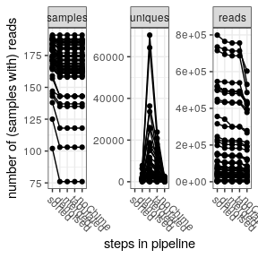

```r
tracking <- getPipelineSummary(MA)
plotPipelineSummary(tracking)
```

The pipeline summary tells us how many samples, how many unique sequences and how many sequence read (pairs) in total were recovered through the pipeline for different amplicons.

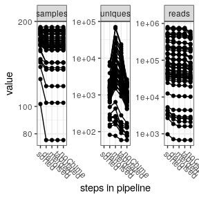

```r
library(ggplot2)
plotPipelineSummary(tracking) + scale_y_log10()
```

The output of the pipeline summary can be modified with standard ggplot syntax.

## Hand over to phyloseq

```r
library(phyloseq)
PH <- toPhyloseq(MA, samples=colnames(MA))
```

[output not shown]

[output cut: 42 more lines]

[output not shown]

```r
PHlist <- toPhyloseq(MA, samples=colnames(MA), multi2Single=FALSE)
```

[output not shown]

[output cut: 42 more lines]

[output not shown]